# Eden Hazard Performance for Chelsea

Aditya Kaul

10/7/2017

## Library Import

```r
library(ggplot2)
library(dplyr)
library(htmltab)
library(tidyr)
library(RColorBrewer)
library(wordcloud)
```

## Data Import

- Provide the year for the data import function
- The year is fed into the url which scrapes the data for Eden Hazard for the premier league
- The data is stored in a variable and then we change the column names

```r
data_import_fn <- function(year){

url <- "https://www.transfermarkt.co.uk/eden-hazard/leistungsdatendetails/spieler/50202/saison/YYYY/verein/631/liga/0/wettbewerb//pos/0/trainer_id/0/plus/1"

updated_url <- gsub('YYYY',as.character(year),url)

num <- 1
new_data <- htmltab(doc = updated_url, which = num, rm_nodata_cols = F)

while(nrow(new_data) != 38){

  new_data <- htmltab(doc = updated_url, which = num, rm_nodata_cols = F)
  num <- num + 1

}

new_data <- new_data %>%
  setNames(c("GW", "Date", "Home_Team1", "Home_Team", "Visiting_Team1", "Visiting_Team",
                        "Result", "Position", "Goals_Scored", "Assists", "Own_Goals", "Yellow_Cards",
                        "Two_Yellows", "Red_Cards", "Substituted_In", "Substituted_Out", "Minutes_Played"))

#colnames(new_data) <- c("GW", "Date", "Home_Team1", "Home_Team", "Visiting_Team1", "Visiting_Team",
#                        "Result", "Position", "Goals_Scored", "Assists", "Own_Goals", "Yellow_Cards",
#                        "Two_Yellows", "Red_Cards", "Substituted_In", "Substituted_Out", "Minutes_Played")

#new_data$Home_Team1 <- NULL
#new_data$Visiting_Team1 <- NULL

new_data <- new_data %>%
  select(-c(Home_Team1, Visiting_Team1))

return(new_data)

}
```

- Create different data frames for the different years

```r
yearly_data_2012 <- data_import_fn(2012)
yearly_data_2013 <- data_import_fn(2013)
yearly_data_2014 <- data_import_fn(2014)
yearly_data_2015 <- data_import_fn(2015)
yearly_data_2016 <- data_import_fn(2016)
```

## Data Cleaning

- The data cleaning function takes each data frame for different years and performs tidying operations

```r
data_cleaning_fn <- function(df) {
broken_data <- df %>%
  separate(Result, c("Team_Goals_Scored", "Team_Goals_Against"), ":")

broken_data_1 <- broken_data %>%
  separate(Home_Team, c("Home_Team","GW_Position1"), "\\(")

#broken_data_1$GW_Position1 <- gsub(".)", "", broken_data_1$GW_Position1)

broken_data_1 <- broken_data_1 %>%
  mutate(GW_Position1 = gsub(".)", "", broken_data_1$GW_Position1))

broken_data_2 <- broken_data_1 %>%
  separate(Visiting_Team, c("Visiting_Team","GW_Position2"), "\\(")

#broken_data_2$GW_Position2 <- gsub(".)", "", broken_data_2$GW_Position2)

broken_data_2 <- broken_data_2 %>%
  mutate(GW_Position2 = gsub(".)", "", broken_data_2$GW_Position2))

#str(broken_data_2)

broken_data_2 <- broken_data_2 %>%
  mutate(Team_Goals_Scored = as.numeric(broken_data_2$Team_Goals_Scored),
         Team_Goals_Against = as.numeric(broken_data_2$Team_Goals_Against),
         Goals_Scored = as.numeric(broken_data_2$Goals_Scored),
         Assists = as.numeric(broken_data_2$Assists),
         Own_Goals = as.numeric(broken_data_2$Own_Goals))

#broken_data_2$Team_Goals_Scored <- as.numeric(broken_data_2$Team_Goals_Scored)
#broken_data_2$Team_Goals_Against <- as.numeric(broken_data_2$Team_Goals_Against)
#broken_data_2$Goals_Scored <- as.numeric(broken_data_2$Goals_Scored)
#broken_data_2$Assists <- as.numeric(broken_data_2$Assists)
#broken_data_2$Own_Goals <- as.numeric(broken_data_2$Own_Goals)

#Convert the date into a date format to get some time series analysis graphs for the future
broken_data_3 <- broken_data_2 %>%
  separate(Date, c("Date","Year"), ", ")

broken_data_4 <- broken_data_3 %>%
  separate(Date, c("Month","Date"), " ")


#broken_data_4$Month <- gsub('\\s+','',broken_data_4$Month)

broken_data_4 <- broken_data_4 %>%
  mutate(Month = gsub('\\s+','',broken_data_4$Month))

#broken_data_4$Month_No <- ifelse(broken_data_4$Month == 'Jan',1,
#                                 ifelse(broken_data_4$Month == 'Feb',2,
#                                  ifelse(broken_data_4$Month == 'Mar',3,
#                                    ifelse(broken_data_4$Month == 'Apr',4,
#                                      ifelse(broken_data_4$Month == 'May',5,
#                                        ifelse(broken_data_4$Month == 'Jun',6,
#                                          ifelse(broken_data_4$Month == 'Jul',7,
#                                            ifelse(broken_data_4$Month == 'Aug',8,
#                                              ifelse(broken_data_4$Month == 'Sep',9,
#                                                ifelse(broken_data_4$Month == 'Oct',10,
#                                                  ifelse(broken_data_4$Month == 'Nov',11,
#                                                    ifelse(broken_data_4$Month == 'Dec',12,0))))))))))))

broken_data_4 <- broken_data_4 %>%
  mutate(Month_No = ifelse(broken_data_4$Month == 'Jan',1,
                                 ifelse(broken_data_4$Month == 'Feb',2,
                                  ifelse(broken_data_4$Month == 'Mar',3,
                                    ifelse(broken_data_4$Month == 'Apr',4,
                                      ifelse(broken_data_4$Month == 'May',5,
                                        ifelse(broken_data_4$Month == 'Jun',6,
                                          ifelse(broken_data_4$Month == 'Jul',7,
                                            ifelse(broken_data_4$Month == 'Aug',8,
                                              ifelse(broken_data_4$Month == 'Sep',9,
                                                ifelse(broken_data_4$Month == 'Oct',10,
                                                  ifelse(broken_data_4$Month == 'Nov',11,
                                                    ifelse(broken_data_4$Month == 'Dec',12,0)))))))))))))


#broken_data_4$Complete_Date <- paste(broken_data_4$Year,broken_data_4$Month_No,broken_data_4$Date,sep = '-')

broken_data_4 <- broken_data_4 %>%
  mutate(Complete_Date = paste(broken_data_4$Year,broken_data_4$Month_No,broken_data_4$Date,sep = '-'))

#broken_data_4$Complete_Date <- as.Date(broken_data_4$Complete_Date)
#broken_data_4$GW_Position1 <- as.numeric(broken_data_4$GW_Position1)
#broken_data_4$GW_Position2 <- as.numeric(broken_data_4$GW_Position2)

#broken_data_4$Home_Team <- gsub('\\s+','',broken_data_4$Home_Team)
#broken_data_4$Visiting_Team <- gsub('\\s+','',broken_data_4$Visiting_Team)

broken_data_4 <- broken_data_4 %>%
  mutate(Complete_Date = as.Date(broken_data_4$Complete_Date),
         GW_Position1 = as.numeric(broken_data_4$GW_Position1),
         GW_Position2 = as.numeric(broken_data_4$GW_Position2),
         Home_Team = gsub('\\s+','',broken_data_4$Home_Team),
         Visiting_Team = gsub('\\s+','',broken_data_4$Visiting_Team))

#broken_data_4$Team_position <- NULL

#broken_data_4 <- broken_data_4 %>%
#  select(-c(Team_position))

#broken_data_4$Team_position1[broken_data_4$Home_Team == "Chelsea"] <- broken_data_4$GW_Position1
#broken_data_4$Team_position2[broken_data_4$Visiting_Team == "Chelsea"] <- broken_data_4$GW_Position2

broken_data_4 <- broken_data_4 %>%
  mutate(Team_position1 = ifelse(broken_data_4$Home_Team == "Chelsea", broken_data_4$GW_Position1, NA),
         Team_position2 = ifelse(broken_data_4$Visiting_Team == "Chelsea", broken_data_4$GW_Position2, NA))

#broken_data_4$ChelseaPosition <- ifelse(broken_data_4$Home_Team == 'Chelsea', broken_data_4$GW_Position1, NA)
#broken_data_4$ChelseaPositionAll <- ifelse(broken_data_4$Visiting_Team == 'Chelsea', broken_data_4$GW_Position2, broken_data_4$ChelseaPosition)

#If one change is dependent on another then we cant put it in the same mutate, we have to pipe another mutate that is dependent on the previous data
broken_data_4 <- broken_data_4 %>%
  mutate(ChelseaPosition = ifelse(broken_data_4$Home_Team == 'Chelsea', broken_data_4$GW_Position1, NA))

broken_data_4 <- broken_data_4 %>%
  mutate(ChelseaPositionAll = ifelse(broken_data_4$Visiting_Team == 'Chelsea', broken_data_4$GW_Position2, broken_data_4$ChelseaPosition))


#broken_data_4$OpponentPosition <- ifelse(broken_data_4$Home_Team != 'Chelsea', broken_data_4$GW_Position1, NA)
#broken_data_4$OpponentPositionAll <- ifelse(broken_data_4$Visiting_Team != 'Chelsea', broken_data_4$GW_Position2, broken_data_4$OpponentPosition)

broken_data_4 <- broken_data_4 %>%
  mutate(OpponentPosition = ifelse(broken_data_4$Home_Team != 'Chelsea', broken_data_4$GW_Position1, NA))

broken_data_4 <- broken_data_4 %>%
  mutate(OpponentPositionAll = ifelse(broken_data_4$Visiting_Team != 'Chelsea', broken_data_4$GW_Position2, broken_data_4$OpponentPosition))

#broken_data_4$Team_position1 <- broken_data_4$GW_Position1[broken_data_4$Home_Team == "Chelsea"]
#broken_data_4$Team_position2 <- broken_data_4$GW_Position2[broken_data_4$Visiting_Team == "Chelsea"]

#broken_data_4$Played_Game <- grepl("'",broken_data_4$Minutes_Played)

#broken_data_4$ChelseaGoal <- ifelse(broken_data_4$Home_Team == 'Chelsea', broken_data_4$Team_Goals_Scored, NA)
#broken_data_4$ChelseaGoalAll <- ifelse(broken_data_4$Visiting_Team == 'Chelsea', broken_data_4$Team_Goals_Against, broken_data_4$ChelseaGoal)

#broken_data_4$OpponentGoal <- ifelse(broken_data_4$Home_Team != 'Chelsea', broken_data_4$Team_Goals_Scored, NA)
#broken_data_4$OpponentGoalAll <- ifelse(broken_data_4$Visiting_Team != 'Chelsea', broken_data_4$Team_Goals_Against, broken_data_4$OpponentGoal)

broken_data_4 <- broken_data_4 %>%
  mutate(Team_position1 = ifelse(broken_data_4$Home_Team == 'Chelsea', broken_data_4$GW_Position1, NA),
         Team_position2 = ifelse(broken_data_4$Visiting_Team == 'Chelsea', broken_data_4$GW_Position2, NA))

broken_data_4 <- broken_data_4 %>%
  mutate(Played_Game = grepl("'",broken_data_4$Minutes_Played))

broken_data_4 <- broken_data_4 %>%
  mutate(ChelseaGoal = ifelse(broken_data_4$Home_Team == 'Chelsea', broken_data_4$Team_Goals_Scored, NA))

broken_data_4 <- broken_data_4 %>%
  mutate(ChelseaGoalAll = ifelse(broken_data_4$Visiting_Team == 'Chelsea', broken_data_4$Team_Goals_Against, broken_data_4$ChelseaGoal))

broken_data_4 <- broken_data_4 %>%
  mutate(OpponentGoal = ifelse(broken_data_4$Home_Team != 'Chelsea', broken_data_4$Team_Goals_Scored, NA))

broken_data_4 <- broken_data_4 %>%
  mutate(OpponentGoalAll = ifelse(broken_data_4$Visiting_Team != 'Chelsea', broken_data_4$Team_Goals_Against, broken_data_4$OpponentGoal))


#broken_data_4$Result <- ifelse(broken_data_4$ChelseaGoalAll - broken_data_4$OpponentGoalAll > 0, 'W',
#                               ifelse(broken_data_4$ChelseaGoalAll - broken_data_4$OpponentGoalAll == 0, 'D', 'L'))

broken_data_4 <- broken_data_4 %>%
  mutate(Result = ifelse(broken_data_4$ChelseaGoalAll - broken_data_4$OpponentGoalAll > 0, 'W',
                               ifelse(broken_data_4$ChelseaGoalAll - broken_data_4$OpponentGoalAll == 0, 'D', 'L')))

#broken_data_4$Goal_Y_N <- ifelse(broken_data_4$Goals_Scored != 0, 1, 0)
#broken_data_4$Assist_Y_N <- ifelse(broken_data_4$Assists != 0, 1, 0)
#broken_data_4$Carded_Y_N <- ifelse(broken_data_4$Yellow_Cards != 0 |
#                                     broken_data_4$Red_Cards != 0 |
#                                     broken_data_4$Two_Yellows != 0, 1, 0)


broken_data_4 <- broken_data_4 %>%
  mutate(Goal_Y_N = ifelse(broken_data_4$Goals_Scored != 0, 1, 0),
         Assist_Y_N = ifelse(broken_data_4$Assists != 0, 1, 0),
         Carded_Y_N = ifelse(broken_data_4$Yellow_Cards != 0 |
                                     broken_data_4$Red_Cards != 0 |
                                     broken_data_4$Two_Yellows != 0, 1, 0))


broken_data_4[is.na(broken_data_4)] <- 0

#broken_data_4$Goal_Y_N <- as.factor(broken_data_4$Goal_Y_N)
#broken_data_4$Played_Game <- as.character(broken_data_4$Played_Game)
#broken_data_4$Minutes_Played_No <- as.numeric(gsub("'", "", broken_data_4$Minutes_Played))
#broken_data_4$Minutes_Played <- as.factor(gsub(" ", "_", broken_data_4$Minutes_Played))

broken_data_4 <- broken_data_4 %>%
  mutate(Goal_Y_N = as.factor(broken_data_4$Goal_Y_N),
         Played_Game = as.character(broken_data_4$Played_Game),
         Minutes_Played_No = as.numeric(gsub("'", "", broken_data_4$Minutes_Played)),
         Minutes_Played = as.factor(gsub(" ", "_", broken_data_4$Minutes_Played)))


broken_data_4[is.na(broken_data_4)] <- 0

return(broken_data_4)
}
```

- Use the data cleaning function for each yearly data frame and obtain the final data frames on which the analysis will be performed

```r
data_2012 <- data_cleaning_fn(yearly_data_2012)
data_2013 <- data_cleaning_fn(yearly_data_2013)
data_2014 <- data_cleaning_fn(yearly_data_2014)
data_2015 <- data_cleaning_fn(yearly_data_2015)
data_2016 <- data_cleaning_fn(yearly_data_2016)
```

- Leverage the multiple plot function from cookbook-r to create multiple ggplots in the same frame

```r
#Using the multiple plot function from cookbook-r.com
# Multiple plot function
#
# ggplot objects can be passed in ..., or to plotlist (as a list of ggplot objects)
# - cols:   Number of columns in layout
# - layout: A matrix specifying the layout. If present, 'cols' is ignored.
#
# If the layout is something like matrix(c(1,2,3,3), nrow=2, byrow=TRUE),
# then plot 1 will go in the upper left, 2 will go in the upper right, and
# 3 will go all the way across the bottom.
#
multiplot <- function(..., plotlist=NULL, file, cols=1, layout=NULL) {
  library(grid)

  # Make a list from the ... arguments and plotlist
  plots <- c(list(...), plotlist)

  numPlots = length(plots)

  # If layout is NULL, then use 'cols' to determine layout
  if (is.null(layout)) {
    # Make the panel
    # ncol: Number of columns of plots
    # nrow: Number of rows needed, calculated from # of cols
    layout <- matrix(seq(1, cols * ceiling(numPlots/cols)),
                     ncol = cols, nrow = ceiling(numPlots/cols))
  }

  if (numPlots==1) {
    print(plots[[1]])

  } else {
    # Set up the page
    grid.newpage()
    pushViewport(viewport(layout = grid.layout(nrow(layout), ncol(layout))))

    # Make each plot, in the correct location
    for (i in 1:numPlots) {
      # Get the i,j matrix positions of the regions that contain this subplot
      matchidx <- as.data.frame(which(layout == i, arr.ind = TRUE))

      print(plots[[i]], vp = viewport(layout.pos.row = matchidx$row,
                                      layout.pos.col = matchidx$col))
    }
  }
}
```

- This plot shows Chelsea’s position after each game week in the league
- The color distinction is to show whether Chelsea’s performance significantly dipped or improved in Eden Hazards absence

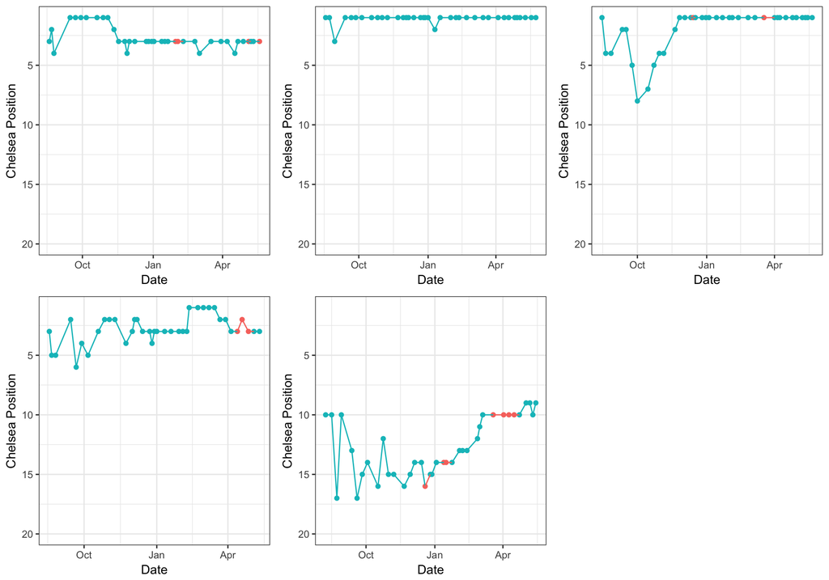

```r
levels(data_2012$Played_Game) <- c("FALSE", "TRUE")
levels(data_2013$Played_Game) <- c("FALSE", "TRUE")
levels(data_2014$Played_Game) <- c("FALSE", "TRUE")
levels(data_2015$Played_Game) <- c("FALSE", "TRUE")
levels(data_2016$Played_Game) <- c("FALSE", "TRUE")

p_2012 <- ggplot(data = data_2012, aes(x = Complete_Date, y = ChelseaPositionAll, group = 1, color = as.factor(Played_Game))) +
  geom_point() +
  geom_line() +
  theme_bw() +
  theme(legend.position="none") +
  scale_y_reverse(lim = c(20,1)) +
  scale_colour_discrete(drop=TRUE, limits = levels(data_2012$Played_Game)) +
  xlab("Date") +
  ylab("Chelsea Position")

p_2013 <- ggplot(data = data_2013, aes(x = Complete_Date, y = ChelseaPositionAll, group = 1, color = as.factor(Played_Game))) +
  geom_point() +
  geom_line() +
  theme_bw() +
  theme(legend.position="none") +
  scale_y_reverse(lim = c(20,1)) +
  scale_colour_discrete(drop=TRUE, limits = levels(data_2013$Played_Game)) +
  xlab("Date") +
  ylab("Chelsea Position")

p_2014 <- ggplot(data = data_2014, aes(x = Complete_Date, y = ChelseaPositionAll, group = 1, color = as.factor(Played_Game))) +
  geom_point() +
  geom_line() +
  theme_bw() +
  theme(legend.position="none") +
  scale_y_reverse(lim = c(20,1)) +
  scale_colour_discrete(drop=TRUE, limits = levels(data_2014$Played_Game)) +
  xlab("Date") +
  ylab("Chelsea Position")

p_2015 <- ggplot(data = data_2015, aes(x = Complete_Date, y = ChelseaPositionAll, group = 1, color = as.factor(Played_Game))) +
  geom_point() +
  geom_line() +
  theme_bw() +
  theme(legend.position="none") +
  scale_y_reverse(lim = c(20,1)) +
  scale_colour_discrete(drop=TRUE, limits = levels(data_2015$Played_Game)) +
  xlab("Date") +
  ylab("Chelsea Position")

p_2016 <- ggplot(data = data_2016, aes(x = Complete_Date, y = ChelseaPositionAll, group = 1, color = as.factor(Played_Game))) +
  geom_point() +
  geom_line() +
  theme_bw() +
  theme(legend.position="none") +
  scale_y_reverse(lim = c(20,1)) +
  scale_colour_discrete(drop=TRUE, limits = levels(data_2016$Played_Game)) +
  xlab("Date") +
  ylab("Chelsea Position")

multiplot(p_2012, p_2013, p_2014, p_2015, p_2016, cols = 3)
```

- This plot shows Chelsea’s position after each game week in the league
- The color distinction is to show whether Chelsea’s performance significantly dipped or improved when Eden Hazard scored goals in a game

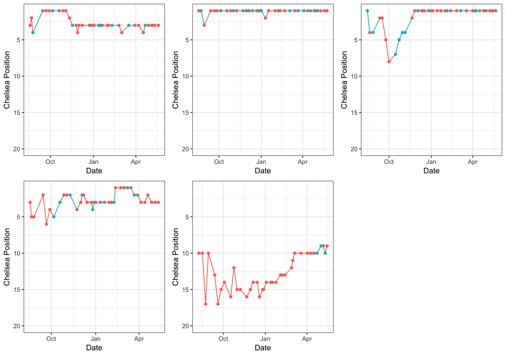

```r
levels(data_2012$Goal_Y_N) <- c("0", "1")
levels(data_2013$Goal_Y_N) <- c("0", "1")
levels(data_2014$Goal_Y_N) <- c("0", "1")
levels(data_2015$Goal_Y_N) <- c("0", "1")
levels(data_2016$Goal_Y_N) <- c("0", "1")

p_2012 <- ggplot(data = data_2012, aes(x = Complete_Date, y = ChelseaPositionAll, group = 1, color = as.factor(Goal_Y_N))) +
  geom_point() +
  geom_line() +
  theme_bw() +
  theme(legend.position="none") +
  scale_y_reverse(lim = c(20,1)) +
  scale_colour_discrete(drop=TRUE, limits = levels(data_2012$Goal_Y_N)) +
  xlab("Date") +
  ylab("Chelsea Position")

p_2013 <- ggplot(data = data_2013, aes(x = Complete_Date, y = ChelseaPositionAll, group = 1, color = as.factor(Goal_Y_N))) +
  geom_point() +
  geom_line() +
  theme_bw() +
  theme(legend.position="none") +
  scale_y_reverse(lim = c(20,1)) +
  scale_colour_discrete(drop=TRUE, limits = levels(data_2013$Goal_Y_N)) +
  xlab("Date") +
  ylab("Chelsea Position")

p_2014 <- ggplot(data = data_2014, aes(x = Complete_Date, y = ChelseaPositionAll, group = 1, color = as.factor(Goal_Y_N))) +
  geom_point() +
  geom_line() +
  theme_bw() +
  theme(legend.position="none") +
  scale_y_reverse(lim = c(20,1)) +
  scale_colour_discrete(drop=TRUE, limits = levels(data_2014$Goal_Y_N)) +
  xlab("Date") +
  ylab("Chelsea Position")

p_2015 <- ggplot(data = data_2015, aes(x = Complete_Date, y = ChelseaPositionAll, group = 1, color = as.factor(Goal_Y_N))) +
  geom_point() +
  geom_line() +
  theme_bw() +
  theme(legend.position="none") +
  scale_y_reverse(lim = c(20,1)) +
  scale_colour_discrete(drop=TRUE, limits = levels(data_2015$Goal_Y_N)) +
  xlab("Date") +
  ylab("Chelsea Position")

p_2016 <- ggplot(data = data_2016, aes(x = Complete_Date, y = ChelseaPositionAll, group = 1, color = as.factor(Goal_Y_N))) +
  geom_point() +
  geom_line() +
  theme_bw() +
  theme(legend.position="none") +
  scale_y_reverse(lim = c(20,1)) +
  scale_colour_discrete(drop=TRUE, limits = levels(data_2016$Goal_Y_N)) +
  xlab("Date") +
  ylab("Chelsea Position")

multiplot(p_2012, p_2013, p_2014, p_2015, p_2016, cols = 3)
```

- This plot shows Chelsea’s position after each game week in the league
- The color distinction is to show whether Chelsea’s performance significantly dipped or improved when Eden Hazard assisted in a game

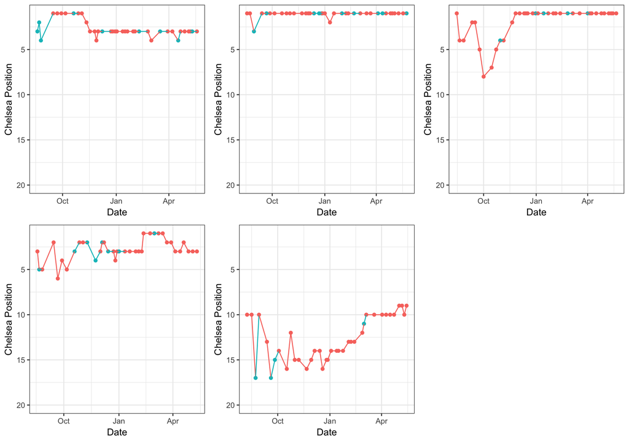

```r
levels(data_2012$Assist_Y_N) <- c("0", "1")
levels(data_2013$Assist_Y_N) <- c("0", "1")
levels(data_2014$Assist_Y_N) <- c("0", "1")
levels(data_2015$Assist_Y_N) <- c("0", "1")
levels(data_2016$Assist_Y_N) <- c("0", "1")

p_2012 <- ggplot(data = data_2012, aes(x = Complete_Date, y = ChelseaPositionAll, group = 1, color = as.factor(Assist_Y_N))) +
  geom_point() +
  geom_line() +
  theme_bw() +
  theme(legend.position="none") +
  scale_y_reverse(lim = c(20,1)) +
  scale_colour_discrete(drop=TRUE, limits = levels(data_2012$Assist_Y_N)) +
  xlab("Date") +
  ylab("Chelsea Position")

p_2013 <- ggplot(data = data_2013, aes(x = Complete_Date, y = ChelseaPositionAll, group = 1, color = as.factor(Assist_Y_N))) +
  geom_point() +
  geom_line() +
  theme_bw() +
  theme(legend.position="none") +
  scale_y_reverse(lim = c(20,1)) +
  scale_colour_discrete(drop=TRUE, limits = levels(data_2013$Assist_Y_N)) +
  xlab("Date") +
  ylab("Chelsea Position")

p_2014 <- ggplot(data = data_2014, aes(x = Complete_Date, y = ChelseaPositionAll, group = 1, color = as.factor(Assist_Y_N))) +
  geom_point() +
  geom_line() +
  theme_bw() +
  theme(legend.position="none") +
  scale_y_reverse(lim = c(20,1)) +
  scale_colour_discrete(drop=TRUE, limits = levels(data_2014$Assist_Y_N)) +
  xlab("Date") +
  ylab("Chelsea Position")

p_2015 <- ggplot(data = data_2015, aes(x = Complete_Date, y = ChelseaPositionAll, group = 1, color = as.factor(Assist_Y_N))) +
  geom_point() +
  geom_line() +
  theme_bw() +
  theme(legend.position="none") +
  scale_y_reverse(lim = c(20,1)) +
  scale_colour_discrete(drop=TRUE, limits = levels(data_2015$Assist_Y_N)) +
  xlab("Date") +
  ylab("Chelsea Position")

p_2016 <- ggplot(data = data_2016, aes(x = Complete_Date, y = ChelseaPositionAll, group = 1, color = as.factor(Assist_Y_N))) +
  geom_point() +
  geom_line() +
  theme_bw() +
  theme(legend.position="none") +
  scale_y_reverse(lim = c(20,1)) +
  scale_colour_discrete(drop=TRUE, limits = levels(data_2016$Assist_Y_N)) +
  xlab("Date") +
  ylab("Chelsea Position")

multiplot(p_2012, p_2013, p_2014, p_2015, p_2016, cols = 3)
```

- This plot shows Chelsea’s position after each game week in the league
- The color distinction is to show whether Chelsea’s performance significantly dipped or improved when Eden Hazard was carded in a game

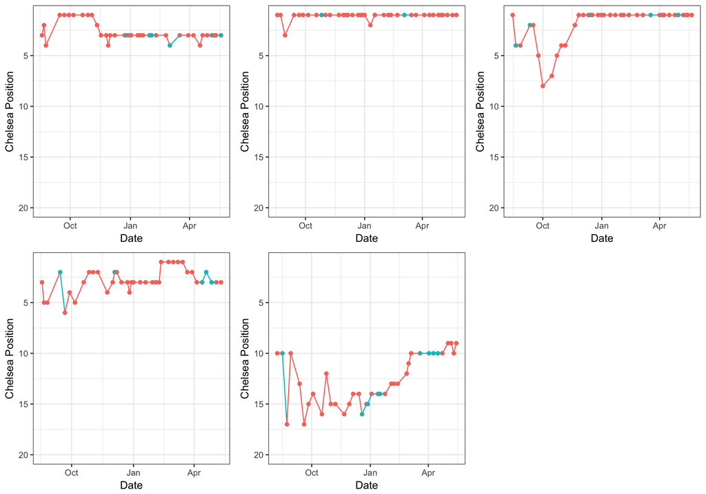

```r
levels(data_2012$Carded_Y_N) <- c("0", "1")
levels(data_2013$Carded_Y_N) <- c("0", "1")
levels(data_2014$Carded_Y_N) <- c("0", "1")
levels(data_2015$Carded_Y_N) <- c("0", "1")
levels(data_2016$Carded_Y_N) <- c("0", "1")

p_2012 <- ggplot(data = data_2012, aes(x = Complete_Date, y = ChelseaPositionAll, group = 1, color = as.factor(Carded_Y_N))) +
  geom_point() +
  geom_line() +
  theme_bw() +
  theme(legend.position="none") +
  scale_y_reverse(lim = c(20,1)) +
  scale_colour_discrete(drop=TRUE, limits = levels(data_2012$Carded_Y_N)) +
  xlab("Date") +
  ylab("Chelsea Position")

p_2013 <- ggplot(data = data_2013, aes(x = Complete_Date, y = ChelseaPositionAll, group = 1, color = as.factor(Carded_Y_N))) +
  geom_point() +
  geom_line() +
  theme_bw() +
  theme(legend.position="none") +
  scale_y_reverse(lim = c(20,1)) +
  scale_colour_discrete(drop=TRUE, limits = levels(data_2013$Carded_Y_N)) +
  xlab("Date") +
  ylab("Chelsea Position")

p_2014 <- ggplot(data = data_2014, aes(x = Complete_Date, y = ChelseaPositionAll, group = 1, color = as.factor(Carded_Y_N))) +
  geom_point() +
  geom_line() +
  theme_bw() +
  theme(legend.position="none") +
  scale_y_reverse(lim = c(20,1)) +
  scale_colour_discrete(drop=TRUE, limits = levels(data_2014$Carded_Y_N)) +
  xlab("Date") +
  ylab("Chelsea Position")

p_2015 <- ggplot(data = data_2015, aes(x = Complete_Date, y = ChelseaPositionAll, group = 1, color = as.factor(Carded_Y_N))) +
  geom_point() +
  geom_line() +
  theme_bw() +
  theme(legend.position="none") +
  scale_y_reverse(lim = c(20,1)) +
  scale_colour_discrete(drop=TRUE, limits = levels(data_2015$Carded_Y_N)) +
  xlab("Date") +
  ylab("Chelsea Position")

p_2016 <- ggplot(data = data_2016, aes(x = Complete_Date, y = ChelseaPositionAll, group = 1, color = as.factor(Carded_Y_N))) +
  geom_point() +
  geom_line() +
  theme_bw() +
  theme(legend.position="none") +
  scale_y_reverse(lim = c(20,1)) +
  scale_colour_discrete(drop=TRUE, limits = levels(data_2016$Carded_Y_N)) +
  xlab("Date") +
  ylab("Chelsea Position")

multiplot(p_2012, p_2013, p_2014, p_2015, p_2016, cols = 3)
```

- The below plots show how many games Chelsea won, lost or drew in Eden Hazards presence or absence

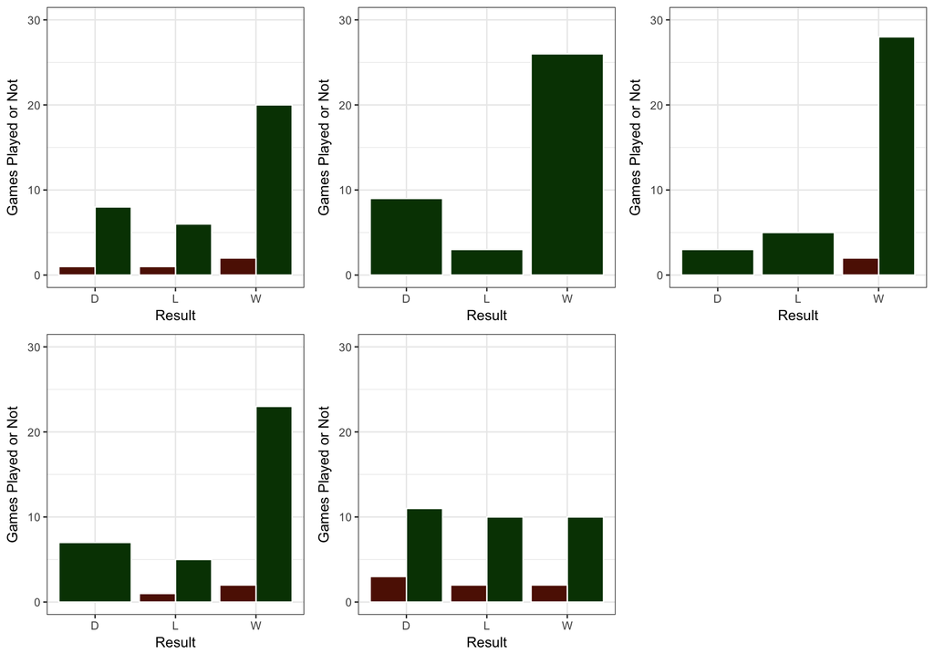

```r
levels(data_2012$Played_Game) <- c("TRUE", "FALSE")
levels(data_2013$Played_Game) <- c("TRUE", "FALSE")
levels(data_2014$Played_Game) <- c("TRUE", "FALSE")
levels(data_2015$Played_Game) <- c("TRUE", "FALSE")
levels(data_2016$Played_Game) <- c("TRUE", "FALSE")

p1 <- ggplot(data_2012, aes(x = data_2012$Result)) +
  geom_histogram(stat = "count", aes(fill = as.factor(data_2012$Played_Game)), position = "dodge", color = "white") +
  theme_bw() +
  theme(legend.position="none") +
  scale_fill_manual(values=c("#5e1603", "#033e03")) +
  scale_colour_discrete(drop=TRUE, limits = levels(data_2012$Played_Game)) +
  xlab("Result") +
  ylab("Games Played or Not") +
  ylim(c(0,30))

p2 <- ggplot(data_2013, aes(x = data_2013$Result)) +
  geom_histogram(stat = "count", aes(fill = as.factor(data_2013$Played_Game)), position = "dodge", color = "white") +
  theme_bw() +
  theme(legend.position="none") +
  scale_fill_manual(values=c("#5e1603", "#033e03")) +
  scale_colour_discrete(drop=TRUE, limits = levels(data_2013$Played_Game)) +
  xlab("Result") +
  ylab("Games Played or Not") +
  ylim(c(0,30))

p3 <- ggplot(data_2014, aes(x = data_2014$Result)) +
  geom_histogram(stat = "count", aes(fill = as.factor(data_2014$Played_Game)), position = "dodge", color = "white") +
  theme_bw() +
  theme(legend.position="none") +
  #scale_fill_manual(values=c("#5e1603", "#033e03")) +
  scale_colour_discrete(drop=TRUE, limits = levels(data_2014$Played_Game)) +
  scale_fill_manual(values=c("#033e03", "#5e1603")) +
  xlab("Result") +
  ylab("Games Played or Not") +
  ylim(c(0,30))

p4 <- ggplot(data_2015, aes(x = data_2015$Result)) +
  geom_histogram(stat = "count", aes(fill = as.factor(data_2015$Played_Game)), position = "dodge", color = "white") +
  theme_bw() +
  theme(legend.position="none") +
  scale_fill_manual(values=c("#5e1603", "#033e03")) +
  scale_colour_discrete(drop=TRUE, limits = levels(data_2015$Played_Game)) +
  xlab("Result") +
  ylab("Games Played or Not") +
  ylim(c(0,30))

p5 <- ggplot(data_2016, aes(x = data_2016$Result)) +
  geom_histogram(stat = "count", aes(fill = as.factor(data_2016$Played_Game)), position = "dodge", color = "white") +
  theme_bw() +
  theme(legend.position="none") +
  scale_fill_manual(values=c("#5e1603", "#033e03")) +
  scale_colour_discrete(drop=TRUE, limits = levels(data_2016$Played_Game)) +
  xlab("Result") +
  ylab("Games Played or Not") +
  ylim(c(0,30))

multiplot(p1,p2,p3,p4,p5, cols = 3)
```

- The below plots show how many games Chelsea won, lost or drew when Eden Hazard scored

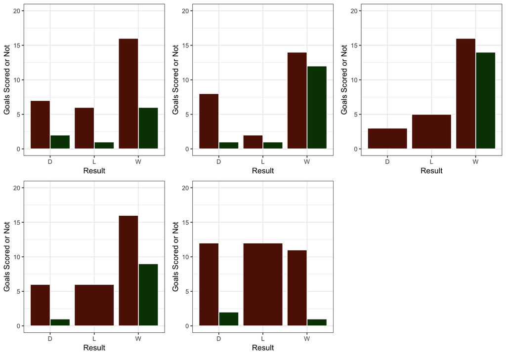

```r
levels(data_2012$Goal_Y_N) <- c("0", "1")
levels(data_2013$Goal_Y_N) <- c("0", "1")
levels(data_2014$Goal_Y_N) <- c("0", "1")
levels(data_2015$Goal_Y_N) <- c("0", "1")
levels(data_2016$Goal_Y_N) <- c("0", "1")

p1 <- ggplot(data_2012, aes(x = data_2012$Result)) +
  geom_histogram(stat = "count", aes(fill = as.factor(data_2012$Goal_Y_N)), position = "dodge", color = "white") +
  theme_bw() +
  theme(legend.position="none") +
  scale_fill_manual(values=c("#5e1603", "#033e03")) +
  scale_colour_discrete(drop=TRUE, limits = levels(data_2012$Goal_Y_N)) +
  xlab("Result") +
  ylab("Goals Scored or Not") +
  ylim(c(0,20))

p2 <- ggplot(data_2013, aes(x = data_2013$Result)) +
  geom_histogram(stat = "count", aes(fill = as.factor(data_2013$Goal_Y_N)), position = "dodge", color = "white") +
  theme_bw() +
  theme(legend.position="none") +
  scale_fill_manual(values=c("#5e1603", "#033e03")) +
  scale_colour_discrete(drop=TRUE, limits = levels(data_2013$Goal_Y_N)) +
  xlab("Result") +
  ylab("Goals Scored or Not") +
  ylim(c(0,20))

p3 <- ggplot(data_2014, aes(x = data_2014$Result)) +
  geom_histogram(stat = "count", aes(fill = as.factor(data_2014$Goal_Y_N)), position = "dodge", color = "white") +
  theme_bw() +
  theme(legend.position="none") +
  scale_fill_manual(values=c("#5e1603", "#033e03")) +
  scale_colour_discrete(drop=TRUE, limits = levels(data_2014$Goal_Y_N)) +
  xlab("Result") +
  ylab("Goals Scored or Not") +
  ylim(c(0,20))

p4 <- ggplot(data_2015, aes(x = data_2015$Result)) +
  geom_histogram(stat = "count", aes(fill = as.factor(data_2015$Goal_Y_N)), position = "dodge", color = "white") +
  theme_bw() +
  theme(legend.position="none") +
  scale_fill_manual(values=c("#5e1603", "#033e03")) +
  scale_colour_discrete(drop=TRUE, limits = levels(data_2015$Goal_Y_N)) +
  xlab("Result") +
  ylab("Goals Scored or Not") +
  ylim(c(0,20))

p5 <- ggplot(data_2016, aes(x = data_2016$Result)) +
  geom_histogram(stat = "count", aes(fill = as.factor(data_2016$Goal_Y_N)), position = "dodge", color = "white") +
  theme_bw() +
  theme(legend.position="none") +
  scale_fill_manual(values=c("#5e1603", "#033e03")) +
  scale_colour_discrete(drop=TRUE, limits = levels(data_2016$Goal_Y_N)) +
  xlab("Result") +
  ylab("Goals Scored or Not") +
  ylim(c(0,20))

multiplot(p1,p2,p3,p4,p5, cols = 3)
```

- The below plots show how many games Chelsea won, lost or drew when Eden Hazard assisted

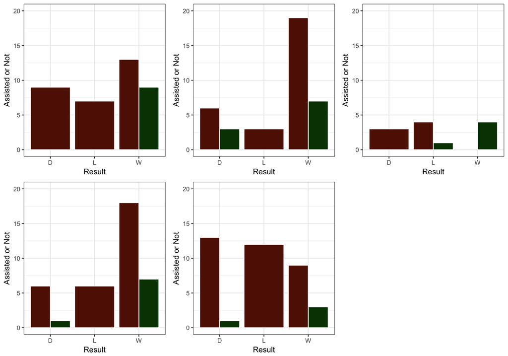

```r
p1 <- ggplot(data_2012, aes(x = data_2012$Result)) +
  geom_histogram(stat = "count", aes(fill = as.factor(data_2012$Assist_Y_N)), position = "dodge", color = "white") +
  theme_bw() +
  theme(legend.position="none") +
  scale_fill_manual(values=c("#5e1603", "#033e03")) +
  xlab("Result") +
  ylab("Assisted or Not") +
  ylim(c(0,20))

p2 <- ggplot(data_2013, aes(x = data_2013$Result)) +
  geom_histogram(stat = "count", aes(fill = as.factor(data_2013$Assist_Y_N)), position = "dodge", color = "white") +
  theme_bw() +
  theme(legend.position="none") +
  scale_fill_manual(values=c("#5e1603", "#033e03")) +
  xlab("Result") +
  ylab("Assisted or Not") +
  ylim(c(0,20))

p3 <- ggplot(data_2014, aes(x = data_2014$Result)) +
  geom_histogram(stat = "count", aes(fill = as.factor(data_2014$Assist_Y_N)), position = "dodge", color = "white") +
  theme_bw() +
  theme(legend.position="none") +
  scale_fill_manual(values=c("#5e1603", "#033e03")) +
  xlab("Result") +
  ylab("Assisted or Not") +
  ylim(c(0,20))

p4 <- ggplot(data_2015, aes(x = data_2015$Result)) +
  geom_histogram(stat = "count", aes(fill = as.factor(data_2015$Assist_Y_N)), position = "dodge", color = "white") +
  theme_bw() +
  theme(legend.position="none") +
  scale_fill_manual(values=c("#5e1603", "#033e03")) +
  xlab("Result") +
  ylab("Assisted or Not") +
  ylim(c(0,20))

p5 <- ggplot(data_2016, aes(x = data_2016$Result)) +
  geom_histogram(stat = "count", aes(fill = as.factor(data_2016$Assist_Y_N)), position = "dodge", color = "white") +
  theme_bw() +
  theme(legend.position="none") +
  scale_fill_manual(values=c("#5e1603", "#033e03")) +
  xlab("Result") +
  ylab("Assisted or Not") +
  ylim(c(0,20))

multiplot(p1,p2,p3,p4,p5, cols = 3)
```

- The below plots show how many games Chelsea won, lost or drew when Eden Hazard was carded

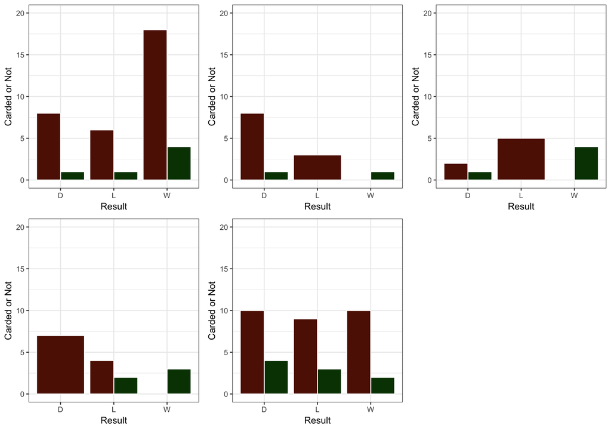

```r
p1 <- ggplot(data_2012, aes(x = data_2012$Result)) +
  geom_histogram(stat = "count", aes(fill = as.factor(data_2012$Carded_Y_N)), position = "dodge", color = "white") +
  theme_bw() +
  theme(legend.position="none") +
  scale_fill_manual(values=c("#5e1603", "#033e03")) +
  xlab("Result") +
  ylab("Carded or Not") +
  ylim(c(0,20))

p2 <- ggplot(data_2013, aes(x = data_2013$Result)) +
  geom_histogram(stat = "count", aes(fill = as.factor(data_2013$Carded_Y_N)), position = "dodge", color = "white") +
  theme_bw() +
  theme(legend.position="none") +
  scale_fill_manual(values=c("#5e1603", "#033e03")) +
  xlab("Result") +
  ylab("Carded or Not") +
  ylim(c(0,20))

p3 <- ggplot(data_2014, aes(x = data_2014$Result)) +
  geom_histogram(stat = "count", aes(fill = as.factor(data_2014$Carded_Y_N)), position = "dodge", color = "white") +
  theme_bw() +
  theme(legend.position="none") +
  scale_fill_manual(values=c("#5e1603", "#033e03")) +
  xlab("Result") +
  ylab("Carded or Not") +
  ylim(c(0,20))

p4 <- ggplot(data_2015, aes(x = data_2015$Result)) +
  geom_histogram(stat = "count", aes(fill = as.factor(data_2015$Carded_Y_N)), position = "dodge", color = "white") +
  theme_bw() +
  theme(legend.position="none") +
  scale_fill_manual(values=c("#5e1603", "#033e03")) +
  xlab("Result") +
  ylab("Carded or Not") +
  ylim(c(0,20))

p5 <- ggplot(data_2016, aes(x = data_2016$Result)) +
  geom_histogram(stat = "count", aes(fill = as.factor(data_2016$Carded_Y_N)), position = "dodge", color = "white") +
  theme_bw() +
  theme(legend.position="none") +
  scale_fill_manual(values=c("#5e1603", "#033e03")) +
  xlab("Result") +
  ylab("Carded or Not") +
  ylim(c(0,20))

multiplot(p1,p2,p3,p4,p5, cols = 3)
```

- The below plot shows the total number of goals scored by Eden Hazard in a specific month

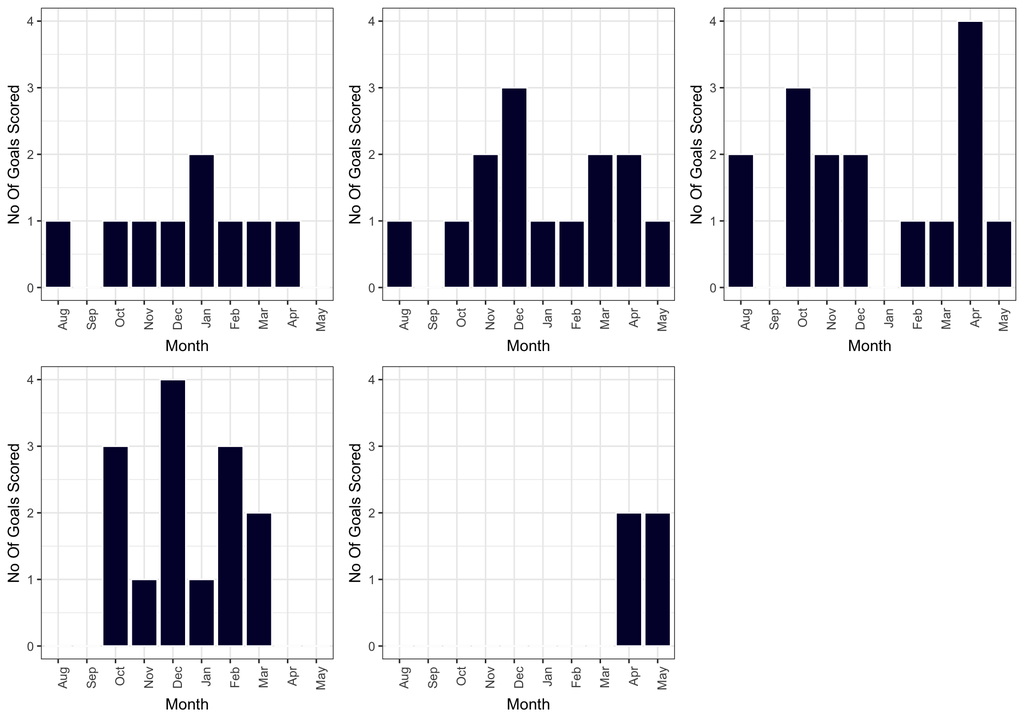

```r
data_2012_goal <- data_2012[,c("Month_No","Goals_Scored")]
grouped_data_2012_goals <- data_2012_goal %>%
  group_by(Month_No) %>%
  summarize(sum(Goals_Scored))

colnames(grouped_data_2012_goals) <- c("Month_No","Goals_Scored")
grouped_data_2012_goals$Month_Name <- c("Jan","Feb","Mar","Apr","May","Aug","Sep","Oct","Nov","Dec")
grouped_data_2012_goals$Month_Name <- factor(grouped_data_2012_goals$Month_Name, levels = c("Aug","Sep","Oct","Nov","Dec","Jan","Feb","Mar","Apr","May"))

p1 <- ggplot(data = grouped_data_2012_goals, aes(x = Month_Name, y = Goals_Scored)) +
  geom_bar(stat = "identity", fill = "#030338", color = "white") +
  theme_bw() +
  theme(axis.text.x = element_text(angle = 90, hjust = 1)) +
  ylim(c(0,4)) +
  xlab("Month") +
  ylab("No Of Goals Scored")

data_2013_goal <- data_2013[,c("Month_No","Goals_Scored")]
grouped_data_2013_goals <- data_2013_goal %>%
  group_by(Month_No) %>%
  summarize(sum(Goals_Scored))

colnames(grouped_data_2013_goals) <- c("Month_No","Goals_Scored")
grouped_data_2013_goals$Month_Name <- c("Jan","Feb","Mar","Apr","May","Aug","Sep","Oct","Nov","Dec")
grouped_data_2013_goals$Month_Name <- factor(grouped_data_2013_goals$Month_Name, levels = c("Aug","Sep","Oct","Nov","Dec","Jan","Feb","Mar","Apr","May"))

p2 <- ggplot(data = grouped_data_2013_goals, aes(x = Month_Name, y = Goals_Scored)) +
  geom_bar(stat = "identity", fill = "#030338", color = "white") +
  theme_bw() +
  theme(axis.text.x = element_text(angle = 90, hjust = 1)) +
  ylim(c(0,4)) +
  xlab("Month") +
  ylab("No Of Goals Scored")


data_2014_goal <- data_2014[,c("Month_No","Goals_Scored")]
data_2014_goal[is.na(data_2014_goal)] <- 0
grouped_data_2014_goals <- data_2014_goal %>%
  group_by(Month_No) %>%
  summarize(sum(Goals_Scored))

colnames(grouped_data_2014_goals) <- c("Month_No","Goals_Scored")
grouped_data_2014_goals$Month_Name <- c("Jan","Feb","Mar","Apr","May","Aug","Sep","Oct","Nov","Dec")
grouped_data_2014_goals$Month_Name <- factor(grouped_data_2014_goals$Month_Name, levels = c("Aug","Sep","Oct","Nov","Dec","Jan","Feb","Mar","Apr","May"))

p3 <- ggplot(data = grouped_data_2014_goals, aes(x = Month_Name, y = Goals_Scored)) +
  geom_bar(stat = "identity", fill = "#030338", color = "white") +
  theme_bw() +
  theme(axis.text.x = element_text(angle = 90, hjust = 1)) +
  ylim(c(0,4)) +
  xlab("Month") +
  ylab("No Of Goals Scored")



data_2015_goal <- data_2015[,c("Month_No","Goals_Scored")]
data_2015_goal[is.na(data_2015_goal)] <- 0
grouped_data_2015_goals <- data_2015_goal %>%
  group_by(Month_No) %>%
  summarize(sum(Goals_Scored))

colnames(grouped_data_2015_goals) <- c("Month_No","Goals_Scored")
grouped_data_2015_goals$Month_Name <- c("Jan","Feb","Mar","Apr","May","Aug","Sep","Oct","Nov","Dec")
grouped_data_2015_goals$Month_Name <- factor(grouped_data_2015_goals$Month_Name, levels = c("Aug","Sep","Oct","Nov","Dec","Jan","Feb","Mar","Apr","May"))

p4 <- ggplot(data = grouped_data_2015_goals, aes(x = Month_Name, y = Goals_Scored)) +
  geom_bar(stat = "identity", fill = "#030338", color = "white") +
  theme_bw() +
  theme(axis.text.x = element_text(angle = 90, hjust = 1)) +
  ylim(c(0,4)) +
  xlab("Month") +
  ylab("No Of Goals Scored")



data_2016_goal <- data_2016[,c("Month_No","Goals_Scored")]
data_2016_goal[is.na(data_2016_goal)] <- 0
grouped_data_2016_goals <- data_2016_goal %>%
  group_by(Month_No) %>%
  summarize(sum(Goals_Scored))

colnames(grouped_data_2016_goals) <- c("Month_No","Goals_Scored")
grouped_data_2016_goals$Month_Name <- c("Jan","Feb","Mar","Apr","May","Aug","Sep","Oct","Nov","Dec")
grouped_data_2016_goals$Month_Name <- factor(grouped_data_2016_goals$Month_Name, levels = c("Aug","Sep","Oct","Nov","Dec","Jan","Feb","Mar","Apr","May"))

p5 <- ggplot(data = grouped_data_2016_goals, aes(x = Month_Name, y = Goals_Scored)) +
  geom_bar(stat = "identity", fill = "#030338", color = "white") +
  theme_bw() +
  theme(axis.text.x = element_text(angle = 90, hjust = 1)) +
  ylim(c(0,4)) +
  xlab("Month") +
  ylab("No Of Goals Scored")


multiplot(p1, p2, p3, p4, p5, cols = 3)
```

- This plot shows the number of assists Eden Hazard created in a particular month during the season

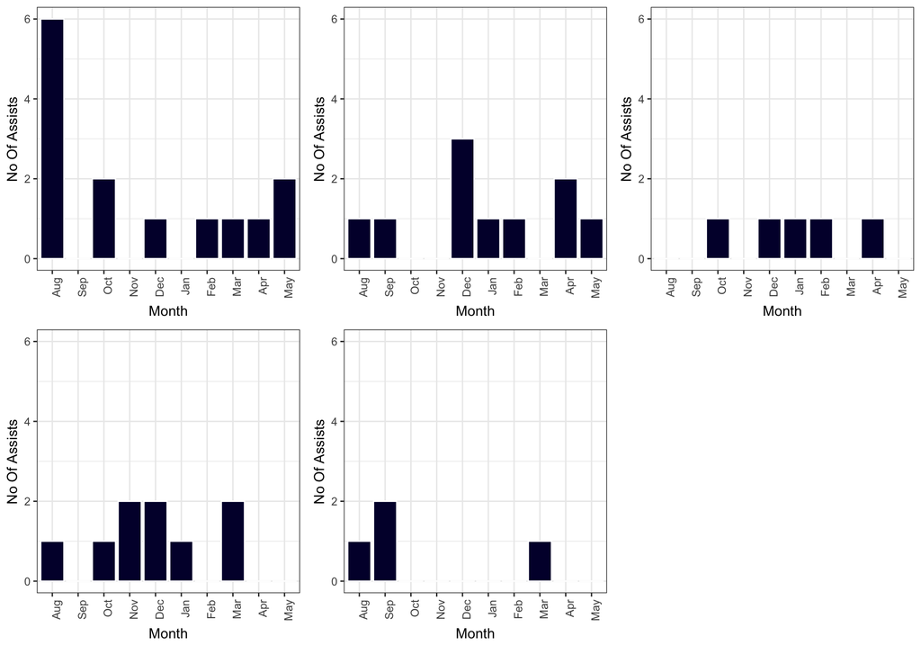

```r
data_2012_assists <- data_2012[,c("Month_No","Assists")]
data_2012_assists[is.na(data_2012_assists)] <- 0
grouped_data_2012_assists <- data_2012_assists %>%
  group_by(Month_No) %>%
  summarize(sum(Assists))

colnames(grouped_data_2012_assists) <- c("Month_No","Assists")
grouped_data_2012_assists$Month_Name <- c("Jan","Feb","Mar","Apr","May","Aug","Sep","Oct","Nov","Dec")
grouped_data_2012_assists$Month_Name <- factor(grouped_data_2012_assists$Month_Name, levels = c("Aug","Sep","Oct","Nov","Dec","Jan","Feb","Mar","Apr","May"))

p1 <- ggplot(data = grouped_data_2012_assists, aes(x = Month_Name, y = Assists)) +
  geom_bar(stat = "identity", fill = "#030338", color = "white") +
  theme_bw() +
  theme(axis.text.x = element_text(angle = 90, hjust = 1)) +
  ylim(c(0,6)) +
  xlab("Month") +
  ylab("No Of Assists")



data_2013_assists <- data_2013[,c("Month_No","Assists")]
data_2013_assists[is.na(data_2013_assists)] <- 0
grouped_data_2013_assists <- data_2013_assists %>%
  group_by(Month_No) %>%
  summarize(sum(Assists))

colnames(grouped_data_2013_assists) <- c("Month_No","Assists")
grouped_data_2013_assists$Month_Name <- c("Jan","Feb","Mar","Apr","May","Aug","Sep","Oct","Nov","Dec")
grouped_data_2013_assists$Month_Name <- factor(grouped_data_2013_assists$Month_Name, levels = c("Aug","Sep","Oct","Nov","Dec","Jan","Feb","Mar","Apr","May"))

p2 <- ggplot(data = grouped_data_2013_assists, aes(x = Month_Name, y = Assists)) +
  geom_bar(stat = "identity", fill = "#030338", color = "white") +
  theme_bw() +
  theme(axis.text.x = element_text(angle = 90, hjust = 1)) +
  ylim(c(0,6)) +
  xlab("Month") +
  ylab("No Of Assists")


data_2014_assists <- data_2014[,c("Month_No","Assists")]
data_2014_assists[is.na(data_2014_assists)] <- 0
grouped_data_2014_assists <- data_2014_assists %>%
  group_by(Month_No) %>%
  summarize(sum(Assists))

colnames(grouped_data_2014_assists) <- c("Month_No","Assists")
grouped_data_2014_assists$Month_Name <- c("Jan","Feb","Mar","Apr","May","Aug","Sep","Oct","Nov","Dec")
grouped_data_2014_assists$Month_Name <- factor(grouped_data_2014_assists$Month_Name, levels = c("Aug","Sep","Oct","Nov","Dec","Jan","Feb","Mar","Apr","May"))

p3 <- ggplot(data = grouped_data_2014_assists, aes(x = Month_Name, y = Assists)) +
  geom_bar(stat = "identity", fill = "#030338", color = "white") +
  theme_bw() +
  theme(axis.text.x = element_text(angle = 90, hjust = 1)) +
  ylim(c(0,6)) +
  xlab("Month") +
  ylab("No Of Assists")


data_2015_assists <- data_2015[,c("Month_No","Assists")]
data_2015_assists[is.na(data_2015_assists)] <- 0
grouped_data_2015_assists <- data_2015_assists %>%
  group_by(Month_No) %>%
  summarize(sum(Assists))

colnames(grouped_data_2015_assists) <- c("Month_No","Assists")
grouped_data_2015_assists$Month_Name <- c("Jan","Feb","Mar","Apr","May","Aug","Sep","Oct","Nov","Dec")
grouped_data_2015_assists$Month_Name <- factor(grouped_data_2015_assists$Month_Name, levels = c("Aug","Sep","Oct","Nov","Dec","Jan","Feb","Mar","Apr","May"))

p4 <- ggplot(data = grouped_data_2015_assists, aes(x = Month_Name, y = Assists)) +
  geom_bar(stat = "identity", fill = "#030338", color = "white") +
  theme_bw() +
  theme(axis.text.x = element_text(angle = 90, hjust = 1)) +
  ylim(c(0,6)) +
  xlab("Month") +
  ylab("No Of Assists")


data_2016_assists <- data_2016[,c("Month_No","Assists")]
data_2016_assists[is.na(data_2016_assists)] <- 0
grouped_data_2016_assists <- data_2016_assists %>%
  group_by(Month_No) %>%
  summarize(sum(Assists))

colnames(grouped_data_2016_assists) <- c("Month_No","Assists")
grouped_data_2016_assists$Month_Name <- c("Jan","Feb","Mar","Apr","May","Aug","Sep","Oct","Nov","Dec")
grouped_data_2016_assists$Month_Name <- factor(grouped_data_2016_assists$Month_Name, levels = c("Aug","Sep","Oct","Nov","Dec","Jan","Feb","Mar","Apr","May"))

p5 <- ggplot(data = grouped_data_2016_assists, aes(x = Month_Name, y = Assists)) +
  geom_bar(stat = "identity", fill = "#030338", color = "white") +
  theme_bw() +
  theme(axis.text.x = element_text(angle = 90, hjust = 1)) +
  ylim(c(0,6)) +
  xlab("Month") +
  ylab("No Of Assists")

multiplot(p1, p2, p3, p4, p5, cols = 3)
```

- The below chart shows the goal difference of each game for Chelsea
- Ideally we would want the histogram to be right skewed which would imply that Chelsea scored more goals than their opponents more number of times which indicates that they won a lot of games

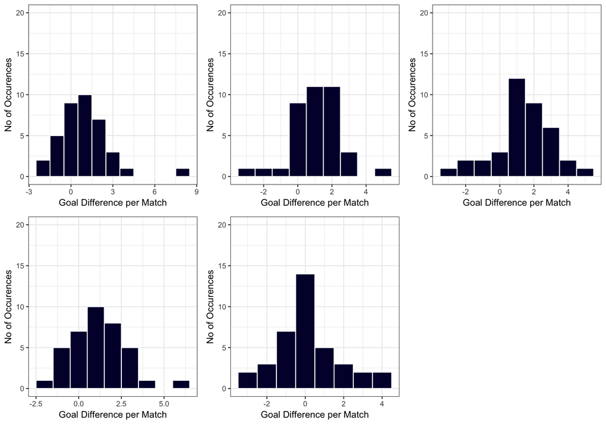

```r
#Fistribution of goals scored
p1 <- ggplot(data = data_2012, aes(data_2012$ChelseaGoalAll - data_2012$OpponentGoalAll)) +
  geom_histogram(binwidth = 1, fill = "#030338", color = "white") +
  theme_bw() +
  ylim(c(0,20)) +
  xlab("Goal Difference per Match") +
  ylab("No of Occurences")

p2 <- ggplot(data = data_2013, aes(data_2013$ChelseaGoalAll - data_2013$OpponentGoalAll)) +
  geom_histogram(binwidth = 1, fill = "#030338", color = "white") +
  theme_bw() +
  ylim(c(0,20)) +
  xlab("Goal Difference per Match") +
  ylab("No of Occurences")

p3 <- ggplot(data = data_2014, aes(data_2014$ChelseaGoalAll - data_2014$OpponentGoalAll)) +
  geom_histogram(binwidth = 1, fill = "#030338", color = "white") +
  theme_bw() +
  ylim(c(0,20)) +
  xlab("Goal Difference per Match") +
  ylab("No of Occurences")

p4 <- ggplot(data = data_2015, aes(data_2015$ChelseaGoalAll - data_2015$OpponentGoalAll)) +
  geom_histogram(binwidth = 1, fill = "#030338", color = "white") +
  theme_bw() +
  ylim(c(0,20)) +
  xlab("Goal Difference per Match") +
  ylab("No of Occurences")

p5 <- ggplot(data = data_2016, aes(data_2016$ChelseaGoalAll - data_2016$OpponentGoalAll)) +
  geom_histogram(binwidth = 1, fill = "#030338", color = "white") +
  theme_bw() +
  ylim(c(0,20)) +
  xlab("Goal Difference per Match") +
  ylab("No of Occurences")


multiplot(p1, p2, p3, p4, p5, cols = 3)
```

- The below chart shows the distribution of the number of goals scored in a match
- This helps us see if Chelsea are a high scoring team over the past few seasons since Eden Hazard has been a part of the team

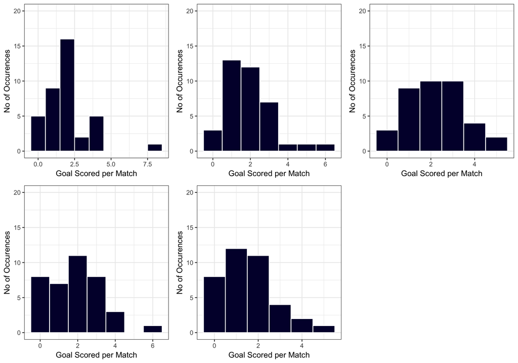

```r
p1 <- ggplot(data = data_2012, aes(data_2012$ChelseaGoalAll)) +
  geom_histogram(binwidth = 1, fill = "#030338", color = "white") +
  theme_bw() +
  ylim(c(0,20)) +
  xlab("Goal Scored per Match") +
  ylab("No of Occurences")

p2 <- ggplot(data = data_2013, aes(data_2013$ChelseaGoalAll)) +
  geom_histogram(binwidth = 1, fill = "#030338", color = "white") +
  theme_bw() +
  ylim(c(0,20)) +
  xlab("Goal Scored per Match") +
  ylab("No of Occurences")

p3 <- ggplot(data = data_2014, aes(data_2014$ChelseaGoalAll)) +
  geom_histogram(binwidth = 1, fill = "#030338", color = "white") +
  theme_bw() +
  ylim(c(0,20)) +
  xlab("Goal Scored per Match") +
  ylab("No of Occurences")

p4 <- ggplot(data = data_2015, aes(data_2015$ChelseaGoalAll)) +
  geom_histogram(binwidth = 1, fill = "#030338", color = "white") +
  theme_bw() +
  ylim(c(0,20)) +
  xlab("Goal Scored per Match") +
  ylab("No of Occurences")

p5 <- ggplot(data = data_2016, aes(data_2016$ChelseaGoalAll)) +
  geom_histogram(binwidth = 1, fill = "#030338", color = "white") +
  theme_bw() +
  ylim(c(0,20)) +
  xlab("Goal Scored per Match") +
  ylab("No of Occurences")

multiplot(p1, p2, p3, p4, p5, cols = 3)
```

- The below chart shows the distribution of the number of goals conceded in a match
- This helps us see if Chelsea are a high concending team over the past few seasons since Eden Hazard has been a part of the team

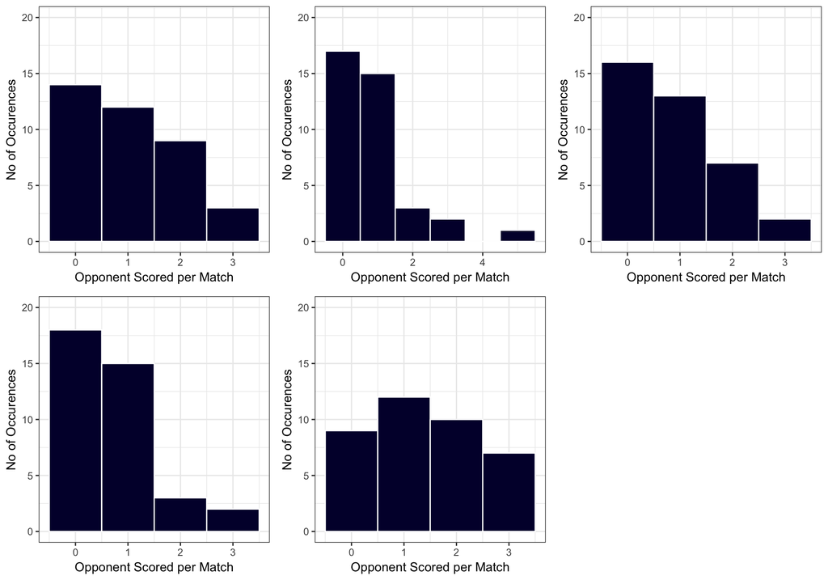

```r
p1 <- ggplot(data = data_2012, aes(data_2012$OpponentGoalAll)) +
  geom_histogram(binwidth = 1, fill = "#030338", color = "white") +
  theme_bw() +
  ylim(c(0,20)) +
  xlab("Opponent Scored per Match") +
  ylab("No of Occurences")

p2 <- ggplot(data = data_2013, aes(data_2013$OpponentGoalAll)) +
  geom_histogram(binwidth = 1, fill = "#030338", color = "white") +
  theme_bw() +
  ylim(c(0,20)) +
  xlab("Opponent Scored per Match") +
  ylab("No of Occurences")

p3 <- ggplot(data = data_2014, aes(data_2014$OpponentGoalAll)) +
  geom_histogram(binwidth = 1, fill = "#030338", color = "white") +
  theme_bw() +
  ylim(c(0,20)) +
  xlab("Opponent Scored per Match") +
  ylab("No of Occurences")

p4 <- ggplot(data = data_2015, aes(data_2015$OpponentGoalAll)) +
  geom_histogram(binwidth = 1, fill = "#030338", color = "white") +
  theme_bw() +
  ylim(c(0,20)) +
  xlab("Opponent Scored per Match") +
  ylab("No of Occurences")

p5 <- ggplot(data = data_2016, aes(data_2016$OpponentGoalAll)) +
  geom_histogram(binwidth = 1, fill = "#030338", color = "white") +
  theme_bw() +
  ylim(c(0,20)) +
  xlab("Opponent Scored per Match") +
  ylab("No of Occurences")

multiplot(p1, p2, p3, p4, p5, cols = 3)
```

- The below plot is a distribution of whether Eden Hazard is a super sub and plays less minutes or does he play the entirity of most of the games

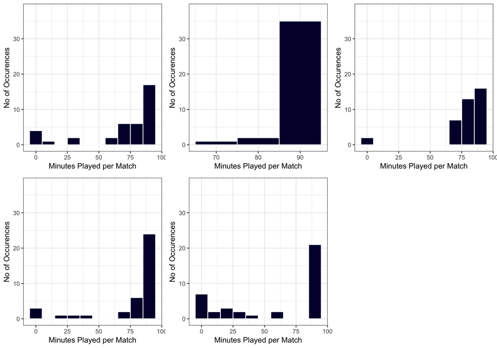

```r
p1 <- ggplot(data = data_2012, aes(data_2012$Minutes_Played_No)) +
  geom_histogram(binwidth = 10, fill = "#030338", color = "white") +
  theme_bw() +
  ylim(c(0,38)) +
  xlab("Minutes Played per Match") +
  ylab("No of Occurences")

p2 <- ggplot(data = data_2013, aes(data_2013$Minutes_Played_No)) +
  geom_histogram(binwidth = 10, fill = "#030338", color = "white") +
  theme_bw() +
  ylim(c(0,38)) +
  xlab("Minutes Played per Match") +
  ylab("No of Occurences")

p3 <- ggplot(data = data_2014, aes(data_2014$Minutes_Played_No)) +
  geom_histogram(binwidth = 10, fill = "#030338", color = "white") +
  theme_bw() +
  ylim(c(0,38)) +
  xlab("Minutes Played per Match") +
  ylab("No of Occurences")

p4 <- ggplot(data = data_2015, aes(data_2015$Minutes_Played_No)) +
  geom_histogram(binwidth = 10, fill = "#030338", color = "white") +
  theme_bw() +
  ylim(c(0,38)) +
  xlab("Minutes Played per Match") +
  ylab("No of Occurences")

p5 <- ggplot(data = data_2016, aes(data_2016$Minutes_Played_No)) +
  geom_histogram(binwidth = 10, fill = "#030338", color = "white") +
  theme_bw() +
  ylim(c(0,38)) +
  xlab("Minutes Played per Match") +
  ylab("No of Occurences")

multiplot(p1, p2, p3, p4, p5, cols = 3)
```

- The word clouds for the different seasons give the reasons why Eden Hazard missed games in the seasons

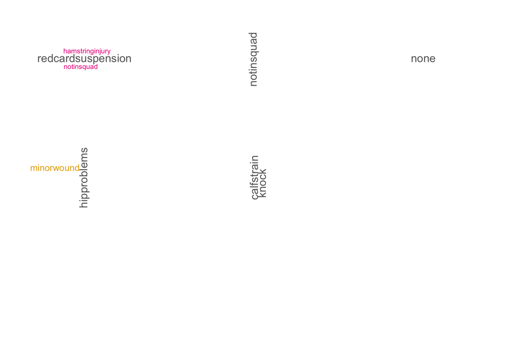

```r
absence_data <- function(df){
  absence_frame <- as.data.frame(df$Minutes_Played[df$Minutes_Played_No == 0])

  return(absence_frame)
}

data_2012_absence <- absence_data(data_2012)
colnames(data_2012_absence) <- c("ReasonForAbsence")
data_2013_absence <- absence_data(data_2013)
colnames(data_2013_absence) <- c("ReasonForAbsence")
data_2014_absence <- absence_data(data_2014)
colnames(data_2014_absence) <- c("ReasonForAbsence")
data_2015_absence <- absence_data(data_2015)
colnames(data_2015_absence) <- c("ReasonForAbsence")
data_2016_absence <- absence_data(data_2016)
colnames(data_2016_absence) <- c("ReasonForAbsence")

par(mfrow=c(3,3))

if(nrow(data_2012_absence) != 0){
  wordcloud(data_2012_absence$ReasonForAbsence,min.freq = 1, scale=c(2,0.5), max.words=2000, random.order=FALSE, rot.per=0.35, use.r.layout=FALSE, colors=brewer.pal(8, "Dark2"))
} else {
  wordcloud("None",min.freq = 1, scale=c(2,0.5), max.words=2000, random.order=FALSE, rot.per=0.35, use.r.layout=FALSE, colors=brewer.pal(8, "Dark2"))
}

if(nrow(data_2013_absence) != 0){
  wordcloud(data_2013_absence$ReasonForAbsence,min.freq = 1, scale=c(2,0.5), max.words=2000, random.order=FALSE, rot.per=0.35, use.r.layout=FALSE, colors=brewer.pal(8, "Dark2"))
} else {
  wordcloud("None",min.freq = 1, scale=c(2,0.5), max.words=2000, random.order=FALSE, rot.per=0.35, use.r.layout=FALSE, colors=brewer.pal(8, "Dark2"))
}

if(nrow(data_2014_absence) != 0){
  wordcloud(data_2014_absence$ReasonForAbsence,min.freq = 1, scale=c(2,0.5), max.words=2000, random.order=FALSE, rot.per=0.35, use.r.layout=FALSE, colors=brewer.pal(8, "Dark2"))
} else {
  wordcloud("None",min.freq = 1, scale=c(2,0.5), max.words=2000, random.order=FALSE, rot.per=0.35, use.r.layout=FALSE, colors=brewer.pal(8, "Dark2"))
}

if(nrow(data_2015_absence) != 0){
  wordcloud(data_2015_absence$ReasonForAbsence,min.freq = 1, scale=c(2,0.5), max.words=2000, random.order=FALSE, rot.per=0.35, use.r.layout=FALSE, colors=brewer.pal(8, "Dark2"))
} else {
  wordcloud("None",min.freq = 1, scale=c(2,0.5), max.words=2000, random.order=FALSE, rot.per=0.35, use.r.layout=FALSE, colors=brewer.pal(8, "Dark2"))
}

if(nrow(data_2016_absence) != 0){
  wordcloud(data_2016_absence$ReasonForAbsence,min.freq = 1, scale=c(2,0.5), max.words=2000, random.order=FALSE, rot.per=0.35, use.r.layout=FALSE, colors=brewer.pal(8, "Dark2"))
} else {
  wordcloud("None",min.freq = 1, scale=c(2,0.5), max.words=2000, random.order=FALSE, rot.per=0.35, use.r.layout=FALSE, colors=brewer.pal(8, "Dark2"))
}
```

- The below plot is a simple representation of how many minutes Eden Hazard played each game week for the different seasons

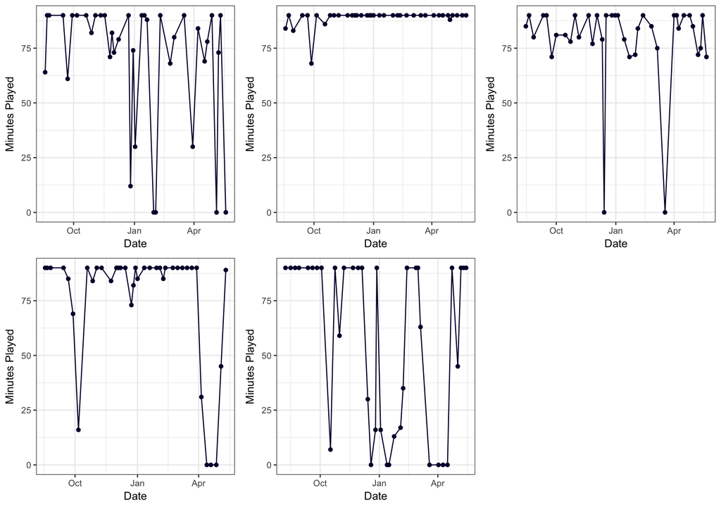

```r
p1 <- ggplot(data = data_2012, aes(x = Complete_Date, y = Minutes_Played_No)) +
  geom_point(colour = "#030338") +
  geom_line(colour = "#030338") +
  theme_bw() +
  ylim(c(0,90)) +
  ylab("Minutes Played") +
  xlab("Date")

p2 <- ggplot(data = data_2013, aes(x = Complete_Date, y = Minutes_Played_No)) +
  geom_point(colour = "#030338") +
  geom_line(colour = "#030338") +
  theme_bw() +
  ylim(c(0,90)) +
  ylab("Minutes Played") +
  xlab("Date")

p3 <- ggplot(data = data_2014, aes(x = Complete_Date, y = Minutes_Played_No)) +
  geom_point(colour = "#030338") +
  geom_line(colour = "#030338") +
  theme_bw() +
  ylim(c(0,90)) +
  ylab("Minutes Played") +
  xlab("Date")

p4 <- ggplot(data = data_2015, aes(x = Complete_Date, y = Minutes_Played_No)) +
  geom_point(colour = "#030338") +
  geom_line(colour = "#030338") +
  theme_bw() +
  ylim(c(0,90)) +
  ylab("Minutes Played") +
  xlab("Date")

p5 <- ggplot(data = data_2016, aes(x = Complete_Date, y = Minutes_Played_No)) +
  geom_point(colour = "#030338") +
  geom_line(colour = "#030338") +
  theme_bw() +
  ylim(c(0,90)) +
  ylab("Minutes Played") +
  xlab("Date")

multiplot(p1, p2, p3, p4, p5, cols = 3)
```

- The below plot shows the number of goals that Eden Hazard scored and the position in the league of the team that he scored it against
- This helps us see if he performs only againsts weak teams or if he is a constant performer versus all teams in the premier league

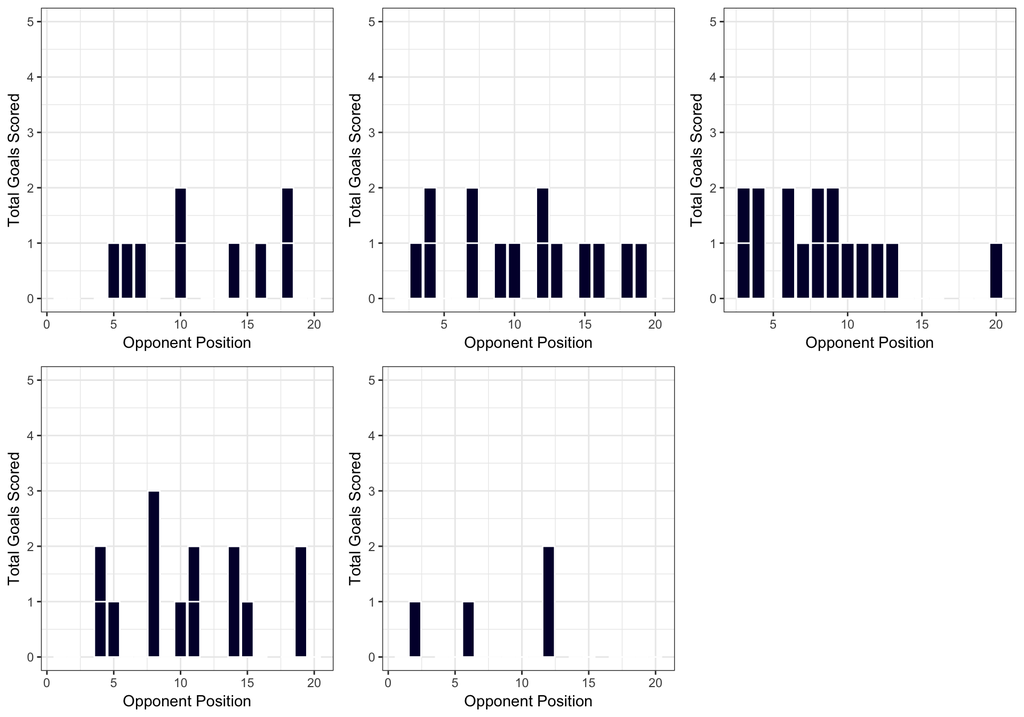

```r
p1 <- ggplot(data_2012, aes(x = OpponentPositionAll, y = as.numeric(Goals_Scored))) +
  geom_histogram(stat = "identity", fill = "#030338", color = "white") +
  ylim(c(0,5)) +
  theme_bw() +
  xlab("Opponent Position") +
  ylab("Total Goals Scored")

p2 <- ggplot(data_2013, aes(x = OpponentPositionAll, y = as.numeric(Goals_Scored))) +
  geom_histogram(stat = "identity", fill = "#030338", color = "white") +
  ylim(c(0,5)) +
  theme_bw() +
  xlab("Opponent Position") +
  ylab("Total Goals Scored")

p3 <- ggplot(data_2014, aes(x = OpponentPositionAll, y = as.numeric(Goals_Scored))) +
  geom_histogram(stat = "identity", fill = "#030338", color = "white") +
  ylim(c(0,5)) +
  theme_bw() +
  xlab("Opponent Position") +
  ylab("Total Goals Scored")

p4 <- ggplot(data_2015, aes(x = OpponentPositionAll, y = as.numeric(Goals_Scored))) +
  geom_histogram(stat = "identity", fill = "#030338", color = "white") +
  ylim(c(0,5)) +
  theme_bw() +
  xlab("Opponent Position") +
  ylab("Total Goals Scored")

p5 <- ggplot(data_2016, aes(x = OpponentPositionAll, y = as.numeric(Goals_Scored))) +
  geom_histogram(stat = "identity", fill = "#030338", color = "white") +
  ylim(c(0,5)) +
  theme_bw() +
  xlab("Opponent Position") +
  ylab("Total Goals Scored")

multiplot(p1, p2, p3, p4, p5, cols = 3)
```

- The below plot shows the number of goals that Eden Hazard assisted and the position in the league of the team that he assisted against
- This helps us see if he performs only againsts weak teams or if he is a constant performer versus all teams in the premier league

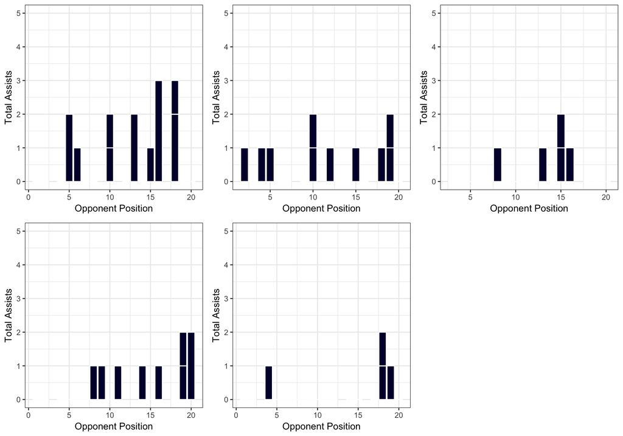

```r
p1 <- ggplot(data_2012, aes(x = OpponentPositionAll, y = as.numeric(Assists))) +
  geom_histogram(stat = "identity", fill = "#030338", color = "white") +
  ylim(c(0,5)) +
  theme_bw() +
  xlab("Opponent Position") +
  ylab("Total Assists")

p2 <- ggplot(data_2013, aes(x = OpponentPositionAll, y = as.numeric(Assists))) +
  geom_histogram(stat = "identity", fill = "#030338", color = "white") +
  ylim(c(0,5)) +
  theme_bw() +
  xlab("Opponent Position") +
  ylab("Total Assists")

p3 <- ggplot(data_2014, aes(x = OpponentPositionAll, y = as.numeric(Assists))) +
  geom_histogram(stat = "identity", fill = "#030338", color = "white") +
  ylim(c(0,5)) +
  theme_bw() +
  xlab("Opponent Position") +
  ylab("Total Assists")

p4 <- ggplot(data_2015, aes(x = OpponentPositionAll, y = as.numeric(Assists))) +
  geom_histogram(stat = "identity", fill = "#030338", color = "white") +
  ylim(c(0,5)) +
  theme_bw() +
  xlab("Opponent Position") +
  ylab("Total Assists")

p5 <- ggplot(data_2016, aes(x = OpponentPositionAll, y = as.numeric(Assists))) +
  geom_histogram(stat = "identity", fill = "#030338", color = "white") +
  ylim(c(0,5)) +
  theme_bw() +
  xlab("Opponent Position") +
  ylab("Total Assists")

multiplot(p1, p2, p3, p4, p5, cols = 3)
```

```r
Minutes_Played_2012 <- sum(data_2012$Minutes_Played_No)
Minutes_Played_2013 <- sum(data_2013$Minutes_Played_No)
Minutes_Played_2014 <- sum(data_2014$Minutes_Played_No)
Minutes_Played_2015 <- sum(data_2015$Minutes_Played_No)
Minutes_Played_2016 <- sum(data_2016$Minutes_Played_No)

Total_Goals_Scored_2012 <- sum(data_2012$Goals_Scored)
Total_Goals_Scored_2013 <- sum(data_2013$Goals_Scored)
Total_Goals_Scored_2014 <- sum(data_2014$Goals_Scored)
Total_Goals_Scored_2015 <- sum(data_2015$Goals_Scored)
Total_Goals_Scored_2016 <- sum(data_2016$Goals_Scored)
Avg_Minutes_Per_Goal_2012 <- round((Minutes_Played_2012/Total_Goals_Scored_2012),2)
Avg_Minutes_Per_Goal_2013 <- round((Minutes_Played_2013/Total_Goals_Scored_2013),2)
Avg_Minutes_Per_Goal_2014 <- round((Minutes_Played_2014/Total_Goals_Scored_2014),2)
Avg_Minutes_Per_Goal_2015 <- round((Minutes_Played_2015/Total_Goals_Scored_2015),2)
Avg_Minutes_Per_Goal_2016 <- round((Minutes_Played_2016/Total_Goals_Scored_2016),2)

Total_Assists_2012 <- sum(data_2012$Assists)
Total_Assists_2013 <- sum(data_2013$Assists)
Total_Assists_2014 <- sum(data_2014$Assists)
Total_Assists_2015 <- sum(data_2015$Assists)
Total_Assists_2016 <- sum(data_2016$Assists)
Avg_Minutes_Per_Assist_2012 <- round((Minutes_Played_2012/Total_Assists_2012),2)
Avg_Minutes_Per_Assist_2013 <- round((Minutes_Played_2013/Total_Assists_2013),2)
Avg_Minutes_Per_Assist_2014 <- round((Minutes_Played_2014/Total_Assists_2014),2)
Avg_Minutes_Per_Assist_2015 <- round((Minutes_Played_2015/Total_Assists_2015),2)
Avg_Minutes_Per_Assist_2016 <- round((Minutes_Played_2016/Total_Assists_2016),2)

League_Position_2012 <- na.omit(ifelse(data_2012$GW == '38', data_2012$ChelseaPositionAll, NA))
League_Position_2013 <- na.omit(ifelse(data_2013$GW == '38', data_2013$ChelseaPositionAll, NA))
League_Position_2014 <- na.omit(ifelse(data_2014$GW == '38', data_2014$ChelseaPositionAll, NA))
League_Position_2015 <- na.omit(ifelse(data_2015$GW == '38', data_2015$ChelseaPositionAll, NA))
League_Position_2016 <- na.omit(ifelse(data_2016$GW == '38', data_2016$ChelseaPositionAll, NA))

Avg_Minutes_Per_Goal_df <- as.data.frame(rbind(Avg_Minutes_Per_Goal_2012,Avg_Minutes_Per_Goal_2013,Avg_Minutes_Per_Goal_2014,
                               Avg_Minutes_Per_Goal_2015,Avg_Minutes_Per_Goal_2016))
rownames(Avg_Minutes_Per_Goal_df) <- NULL
colnames(Avg_Minutes_Per_Goal_df) <- c("Avg_Minutes_Per_Goal")

year_df <- as.data.frame(rbind("2012","2013","2014","2015","2016"))
colnames(year_df) <- c("Year")

Avg_Minutes_Per_Assist_df <- as.data.frame(rbind(Avg_Minutes_Per_Assist_2012,Avg_Minutes_Per_Assist_2013,Avg_Minutes_Per_Assist_2014,
                                                 Avg_Minutes_Per_Assist_2015,Avg_Minutes_Per_Assist_2016))
rownames(Avg_Minutes_Per_Assist_df) <- NULL
colnames(Avg_Minutes_Per_Assist_df) <- c("Avg_Minutes_Per_Assist")

League_Position_df <- as.data.frame(rbind(League_Position_2012,League_Position_2013,League_Position_2014,
                                          League_Position_2015,League_Position_2016))

rownames(League_Position_df) <- NULL
colnames(League_Position_df) <- c("League_Position")

final_df <- cbind(year_df, Avg_Minutes_Per_Goal_df, Avg_Minutes_Per_Assist_df, League_Position_df)

print(final_df)
```

```
##   Year Avg_Minutes_Per_Goal Avg_Minutes_Per_Assist League_Position
## 1 2012               293.11                 188.43               3
## 2 2013               207.00                 322.00               3
## 3 2014               241.36                 337.90               1
## 4 2015               547.75                 547.75               9
## 5 2016               187.81                 601.00               1
```